# RC2 Spatial Analyses

## Analyzing bNTI patterns

```r
### Load in bNTI and calculate averages
# Load in bNTI results
bnti = as.matrix(as.dist(read.csv("Data/RC2_SPS_MCD_bNTI_999.csv", row.names = 1)))

# Reorder bNTI
bnti = bnti[order(row.names(bnti)), order(colnames(bnti))]
bnti[upper.tri(bnti)] = NA
diag(bnti) = NA

# Plotting overall bNTI
plot = as.data.frame(bnti) %>%
  gather(Samples, Values) %>%
  ggplot(aes(x = Values))+
  geom_density(fill = "gray")+
  geom_vline(xintercept = c(-2,2), color = "red", lty = 2)+
  theme_bw()
ggsave("Figures/Supplemental_Figure_3a.pdf", plot)

# Looking at overall bNTI
avg.bnti = as.matrix(as.dist(bnti))
diag(avg.bnti) = NA
avg.bnti = data.frame(Site = colnames(avg.bnti), Mean_bNTI = colMeans(avg.bnti, na.rm = T))

# Calculating within group averages for binned basin area
uniq_so = unique(meta$Stream_Order)
so.bnti = as.matrix(as.dist(bnti))
output = NULL

for(i in 1:length(uniq_so)){
  w = which(meta$Stream_Order %in% uniq_so[i])
  not.w = which(!meta$Stream_Order %in% uniq_so[i])

  # For average
  temp = as.matrix(as.dist(bnti[w,w]))
  diag(temp) = NA

  # For absolute
  so.bnti[w,not.w] = NA
  so.bnti[not.w,w] = NA

  output = rbind(output,
                data.frame(Site = colnames(temp), Mean_bNTI_within_SO = colMeans(temp, na.rm = T)))
}

# Merging into mean bNTI object
avg.bnti = avg.bnti %>% left_join(output, by = "Site")
rm(uniq_so, temp, output)

# Melt and rename variables
avg.bnti = melt(avg.bnti, id.vars = "Site") %>%
  mutate(Metric = case_when(variable == "Mean_bNTI" ~ "Overall",
                            variable == "Mean_bNTI_within_SO" ~ "Within Stream Order"))

# Selecting geospatial variables of interest
cor.spat = meta %>% select(Site, TOT_AET2015_ANN, TOT_PET2015_ANN, TOT_PPT2015_ANN,
                TOT_TAV2015_ANN, TOT_CONTACT, TOT_RECHG, TOT_urban16_sqrt,
                TOT_forest16_sqrt, TOT_wetland16_sqrt, TOT_agrc16_sqrt, TOT_shrub16_sqrt,
                TOT_BASIN_AREA_LOG, `Geospatial PC1`, `Geospatial PC2`, `Geospatial PC3`) # Create correlation object (meta data subset)
row.names(cor.spat) = cor.spat$Site


### Correlating all geospatial variables against average bNTI
geo.stats = NULL # geo.stats == average bNTI correlations

for(curr.met in unique(avg.bnti$variable)){
  temp.bnti = avg.bnti[which(avg.bnti$variable %in% curr.met),]

  # Confirm name orders
  if(!identical(cor.spat$Site, temp.bnti$Site)){
    stop("The order between average bNTI and geospatial data is wrong")
  }

  for(i in 2:ncol(cor.spat)){
    # Univariate/Spearman
    temp.res = rcorr(x = cor.spat[,i], y = temp.bnti$value, type = "spearman")
    temp.out = data.frame(Correlation = paste0(colnames(cor.spat)[i], " vs. ", curr.met),
                          Geospatial_Variable = colnames(cor.spat)[i],
                          bNTI_version = curr.met,
                          rho = temp.res$r[1,2], p_value = temp.res$P[1,2])
    geo.stats = rbind(geo.stats, temp.out)

  }

  rm(temp.bnti, temp.cor, temp.res, temp.out)
}

# Clean up
rm(i, curr.met)

# Adjust p-value
geo.stats$p_value = p.adjust(geo.stats$p_value, method = "fdr")

# Filter out insigniificant comparisons
geo.stats = geo.stats %>% filter(p_value < 0.05)

# Print significant geospatial variables
print(unique(geo.stats$Geospatial_Variable))
```

```
## character(0)
```

```r
### Correlating all geospatial variables against overall bNTI
mult.stats = NULL # mult.stats == Mantel-based correlations

for(i in 2:ncol(cor.spat)){
  if(!identical(row.names(bnti), cor.spat$Site)){
    stop("The order between bNTI and geospatial data is wrong")
  }

  # Multivariate/Mantel
  geo.dist = vegdist(cor.spat[,i, drop = F], method = "euclidean")
  temp.res = mantel(as.dist(bnti), geo.dist, method = "spearman", permutations = 9999)
  temp.out = data.frame(bNTI_Version = "Overall",
                        Geospatial_Variable = colnames(cor.spat)[i],
                        Mantel_rho = temp.res$statistic,
                        p_value = temp.res$signif)
  mult.stats = rbind(mult.stats, temp.out)

  # Within Stream Order Mantel
  temp.res = mantel(as.dist(so.bnti), geo.dist, method = "spearman", permutations = 9999, na.rm = T)
  temp.out = data.frame(bNTI_Version = "Within Stream Order",
                        Geospatial_Variable = colnames(cor.spat)[i],
                        Mantel_rho = temp.res$statistic,
                        p_value = temp.res$signif)
  mult.stats = rbind(mult.stats, temp.out)

  # Clean up
  rm(geo.dist, temp.res, temp.out, bnti.dist)
}

# Print stats
geo.stats
```

```
## [1] Correlation         Geospatial_Variable bNTI_version
## [4] rho                 p_value
## <0 rows> (or 0-length row.names)
```

```r
mult.stats
```

```
##           bNTI_Version Geospatial_Variable      Mantel_rho p_value
## 1              Overall     TOT_AET2015_ANN  0.317289720126  0.0001
## 2  Within Stream Order     TOT_AET2015_ANN  0.402614864302  0.0001
## 3              Overall     TOT_PET2015_ANN  0.378261754536  0.0001
## 4  Within Stream Order     TOT_PET2015_ANN  0.417895677478  0.0001
## 5              Overall     TOT_PPT2015_ANN  0.436444740287  0.0001
## 6  Within Stream Order     TOT_PPT2015_ANN  0.486997571988  0.0001
## 7              Overall     TOT_TAV2015_ANN  0.327629613015  0.0001
## 8  Within Stream Order     TOT_TAV2015_ANN  0.396708971574  0.0001
## 9              Overall         TOT_CONTACT  0.225491260195  0.0006
## 10 Within Stream Order         TOT_CONTACT  0.231700088604  0.0072
## 11             Overall           TOT_RECHG  0.372094297194  0.0001
## 12 Within Stream Order           TOT_RECHG  0.420879633708  0.0001
## 13             Overall    TOT_urban16_sqrt  0.097392182696  0.0518
## 14 Within Stream Order    TOT_urban16_sqrt  0.281971364229  0.0018
```

[output cut: 16 more lines]

```r
# Writing stats
write.csv(geo.stats, "Figures/Supplemental_Table_1_Average_bNTI_Geospatial_Correlations.csv", quote = F)
write.csv(mult.stats, "Figures/Supplemental_Table_1_bNTI_Geospatial_Mantel_Correlations.csv", quote = F)

# Calculating non-linear stats for basin area
stream.bnti = avg.bnti %>% left_join(meta, by = "Site") %>% filter(grepl("Stream", Metric))
non.lin = gam(stream.bnti$value~s(stream.bnti$TOT_BASIN_AREA_LOG))
anova(non.lin)
```

```
##
## Family: gaussian
## Link function: identity
##
## Formula:
## stream.bnti$value ~ s(stream.bnti$TOT_BASIN_AREA_LOG)
##
## Approximate significance of smooth terms:
##                                        edf   Ref.df       F   p-value
## s(stream.bnti$TOT_BASIN_AREA_LOG) 2.542176 3.171920 5.13097 0.0035246
```

```r
rm(stream.bnti)
```

```r
### Correlating all geochemical variables against alpha diversity
cor.geo = geochem %>% mutate(Site = row.names(geochem)) %>%
  select(Site, colnames(geochem))

geo.stats = NULL

for(curr.met in unique(avg.bnti$variable)){
  temp.bnti = avg.bnti[which(avg.bnti$variable %in% curr.met),]

  if(!identical(cor.geo$Site, temp.bnti$Site)){
    stop("The order between average bNTI and geochemical data is wrong")
  }

  for(i in 2:ncol(cor.geo)){
    temp.res = rcorr(x = cor.geo[,i], y = temp.bnti$value, type = "spearman")
    temp.out = data.frame(Correlation = paste0(colnames(cor.geo)[i], " vs. ", curr.met),
                          Geospatial_Variable = colnames(cor.geo)[i],
                          bNTI_version = curr.met,
                          rho = temp.res$r[1,2], p_value = temp.res$P[1,2])
    geo.stats = rbind(geo.stats, temp.out)
  }

  rm(temp.alpha, temp.cor, temp.res, temp.out)
}

# Adjust p-value
geo.stats$p_value = p.adjust(geo.stats$p_value, method = "fdr")

# Filter out insigniificant comparisons
geo.stats = geo.stats %>% filter(p_value < 0.05)


### Correlating all geochemical variables against overall bNTI
mult.stats = NULL

for(i in 2:ncol(cor.geo)){
  if(!identical(row.names(bnti), cor.geo$Site)){
    stop("The order between bNTI and geospatial data is wrong")
  }

  bnti.dist = as.dist(bnti)

  # Multivariate/Mantel
  geo.dist = vegdist(cor.geo[,i], method = "euclidean")
  temp.res = mantel(bnti.dist, geo.dist, method = "spearman", permutations = 9999)
  temp.out = data.frame(bNTI_Version = "Overall",
                        Geospatial_Variable = colnames(cor.geo)[i],
                        Mantel_rho = temp.res$statistic,
                        p_value = temp.res$signif)
  mult.stats = rbind(mult.stats, temp.out)

  # Within Stream Order Mantel
  temp.res = mantel(as.dist(so.bnti), geo.dist, method = "spearman", permutations = 9999, na.rm = T)
  temp.out = data.frame(bNTI_Version = "Within Stream Order",
                        Geospatial_Variable = colnames(cor.geo)[i],
                        Mantel_rho = temp.res$statistic,
                        p_value = temp.res$signif)
  mult.stats = rbind(mult.stats, temp.out)

  # Clean up
  rm(geo.dist, temp.res, temp.out, bnti.dist)
}

# Print stats
geo.stats
```

```
## [1] Correlation         Geospatial_Variable bNTI_version
## [4] rho                 p_value
## <0 rows> (or 0-length row.names)
```

```r
mult.stats
```

```
##           bNTI_Version           Geospatial_Variable    Mantel_rho p_value
## 1              Overall           X00530_TSS_mg_per_L 0.32690431495  0.0001
## 2  Within Stream Order           X00530_TSS_mg_per_L 0.27986161798  0.0040
## 3              Overall  Mean_00691_DIC_mg_per_L_as_C 0.27342663596  0.0001
## 4  Within Stream Order  Mean_00691_DIC_mg_per_L_as_C 0.39552748775  0.0001
## 5              Overall            X00940_Cl_mg_per_L 0.38480316461  0.0001
## 6  Within Stream Order            X00940_Cl_mg_per_L 0.35506258742  0.0002
## 7              Overall    X00945_SO4_mg_per_L_as_SO4 0.27385269954  0.0002
## 8  Within Stream Order    X00945_SO4_mg_per_L_as_SO4 0.28470914845  0.0047
## 9              Overall    X71851_NO3_mg_per_L_as_NO3 0.27577588886  0.0007
## 10 Within Stream Order    X71851_NO3_mg_per_L_as_NO3 0.19972035242  0.0382
## 11             Overall    X71856_NO2_mg_per_L_as_NO2 0.03929569910  0.2930
## 12 Within Stream Order    X71856_NO2_mg_per_L_as_NO2 0.04239097868  0.2654
## 13             Overall Mean_00681_NPOC_mg_per_L_as_C 0.67260464185  0.0001
## 14 Within Stream Order Mean_00681_NPOC_mg_per_L_as_C 0.62282696089  0.0001
## 15             Overall   Mean_00602_TN_mg_per_L_as_N 0.50719322178  0.0001
## 16 Within Stream Order   Mean_00602_TN_mg_per_L_as_N 0.49660852485  0.0001
```

```r
# Writing stats
write.csv(geo.stats, "Figures/Supplemental_Table_1_Average_bNTI_Geochemical_Correlations.csv", quote = F)
write.csv(mult.stats, "Figures/Supplemental_Table_1_bNTI_Geochemical_Mantel_Correlations.csv", quote = F)

# Print significant geospatial variables
print(unique(geo.stats$Geospatial_Variable))
```

```
## character(0)
```

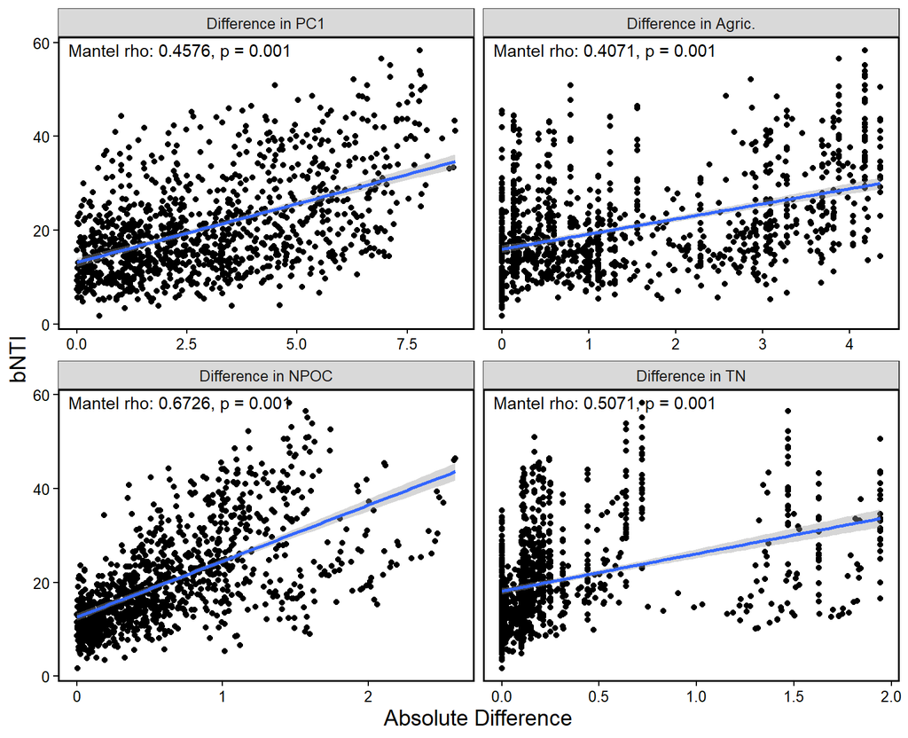

```r
# Create data frame for plotting
plot.data = data.frame(Sites = colnames(bnti),
                       bNTI = melt(as.matrix(bnti))$value,
                       `Difference in PC1` = melt(as.matrix(vegdist(cor.spat$`Geospatial PC1`, method = "euclidean")))$value,
                       `Difference in Agric.` = melt(as.matrix(vegdist(cor.spat$TOT_agrc16_sqrt, method = "euclidean")))$value,
                       `Difference in NPOC` = melt(as.matrix(vegdist(cor.geo$Mean_00681_NPOC_mg_per_L_as_C, method = "euclidean")))$value,
                       `Difference in TN` = melt(as.matrix(vegdist(cor.geo$Mean_00602_TN_mg_per_L_as_N, method = "euclidean")))$value,
                       check.names = F)

plot.data = melt(plot.data, id.vars = c("Sites", "bNTI"))

# Create stats object
signif.obj = data.frame(variable = c("Difference in PC1", "Difference in Agric.", "Difference in NPOC",
                                     "Difference in TN"),
                        stats = c(paste0("Mantel rho: 0.4576, p = 0.001"), paste0("Mantel rho: 0.4071, p = 0.001"),
                                  paste0("Mantel rho: 0.6726, p = 0.001"), paste0("Mantel rho: 0.5071, p = 0.001")))
signif.obj$variable = factor(signif.obj$variable, levels = c("Difference in PC1",
                                                             "Difference in Agric.",
                                                             "Difference in NPOC",
                                                             "Difference in TN"))

# Plot the data
fig.3 = plot.data %>%
  mutate(variable = factor(variable, levels = c("Difference in PC1",
                                                "Difference in Agric.",
                                                "Difference in NPOC",
                                                "Difference in TN"))) %>%
  ggplot(aes(x = value, y = bNTI))+
  geom_point()+
  geom_smooth(method = "lm")+
  xlab("Absolute Difference")+
  facet_wrap(variable~., scale = "free_x")+
      geom_text(data = signif.obj, mapping = aes(x = -Inf, y = Inf, label = stats),
            hjust = -0.05, vjust   = 1.5)+
  theme_bw() + theme(text = element_text(size = 12),
                     axis.title = element_text(color = "black", size = 14),
                     axis.text = element_text(color = "black"),
                     axis.ticks = element_line(color = "black"),
                     panel.border = element_rect(size = 1, color = "black"),
                     panel.background = element_blank(),
                     panel.grid = element_blank())

fig.3
```

```r
ggsave("Figures/Supplemental_Figure_3.pdf", fig.3)

# Clean up
rm(plot, plot.data)
```

Again, we see that NPOC is the most correlated variable across our dataset.

```r
# Plotting betaNTI vs. geospatial patterns
plot1 = plot.alpha.diver(avg.bnti, meta, "Stream_Order") # Included given that it is factorial
plot2 = plot.alpha.diver(avg.bnti, meta, "TOT_BASIN_AREA_LOG")
plot2$Plot$layers = plot2$Plot$layers[-2:-3]
plot2$Plot = plot2$Plot + geom_smooth(method = "gam")

# Combine plots
fig.4 = ggarrange(plot1$Plot + xlab("Stream Order") + ylab("Average bNTI")+
                    theme(axis.text.x = element_text(angle = 0, hjust = 0.5)),
                  plot2$Plot + xlab("log(Tot. Basin Area)") + ylab("Average bNTI"),
                  text_grob(label = paste0("GAM ANOVA for Basin Area vs. Within-Stream Order \n",
                                           "F-stat: ",
                                           round(anova(non.lin)$s.table[,3], digits = 4), "\n",
                                           "p = ",
                                           round(anova(non.lin)$s.table[,4], digits = 4))),
                  ncol = 1, nrow = 3,
                  labels = c("A", "B", "C"))
# Supplemental figure 3 (looking at other non-linear realtionships)
plot1 = plot.alpha.diver(avg.bnti, meta, "TOT_urban16_sqrt") # urban cover
plot1$Plot$layers = plot1$Plot$layers[-2:-3]
plot1$Plot = plot1$Plot + geom_smooth(method = "gam")

plot2 = plot.alpha.diver(avg.bnti, meta, "TOT_forest16_sqrt") # forest cover
plot2$Plot$layers = plot2$Plot$layers[-2:-3]
plot2$Plot = plot2$Plot + geom_smooth(method = "gam")

plot3 = plot.alpha.diver(avg.bnti, meta, "TOT_wetland16_sqrt") # wetland cover
plot3$Plot$layers = plot3$Plot$layers[-2:-3]
plot3$Plot = plot3$Plot + geom_smooth(method = "gam")

plot4 = plot.alpha.diver(avg.bnti, meta, "TOT_agrc16_sqrt") # agrc. cover
plot4$Plot$layers = plot4$Plot$layers[-2:-3]
plot4$Plot = plot4$Plot + geom_smooth(method = "gam")

plot5 = plot.alpha.diver(avg.bnti, meta, "TOT_shrub16_sqrt") # shrub cover
plot5$Plot$layers = plot5$Plot$layers[-2:-3]
plot5$Plot = plot5$Plot + geom_smooth(method = "gam")

plot6 = plot.alpha.diver(avg.bnti, cor.geo, "Mean_00681_NPOC_mg_per_L_as_C") # NPOC
plot6$Plot$layers = plot6$Plot$layers[-2:-3]
plot6$Plot = plot6$Plot + geom_smooth(method = "gam")

# Combine plots
supp.fig.3 = ggarrange(plot1$Plot + xlab("sqrt(Urban) (%)") + ylab("Average bNTI"),
                  plot2$Plot + xlab("sqrt(Forest) (%)") + ylab("Average bNTI"),
                  plot3$Plot + xlab("sqrt(Wetland) (%)") + ylab("Average bNTI"),
                  plot4$Plot + xlab("sqrt(Agric.) (%)") + ylab("Average bNTI"),
                  plot5$Plot + xlab("sqrt(Shrub) (%)") + ylab("Average bNTI"),
                  plot6$Plot + xlab("NPOC (mg/L)") + ylab("Average bNTI"),
                  labels = c("A", "B", "C", "D", "E", "F"))
rm(list = ls(pattern = "^plot[0-9]"))
rm(non.lin)
```

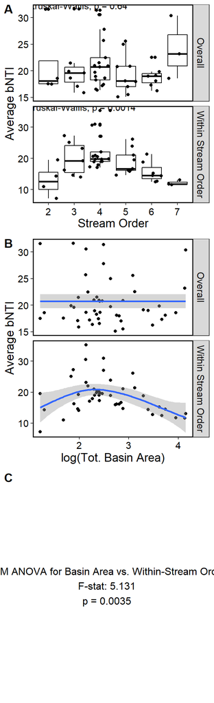

```r
fig.4
```

```r
ggsave("Figures/Figure_4.pdf", fig.4, width = 3.50, height = 11.5)
```

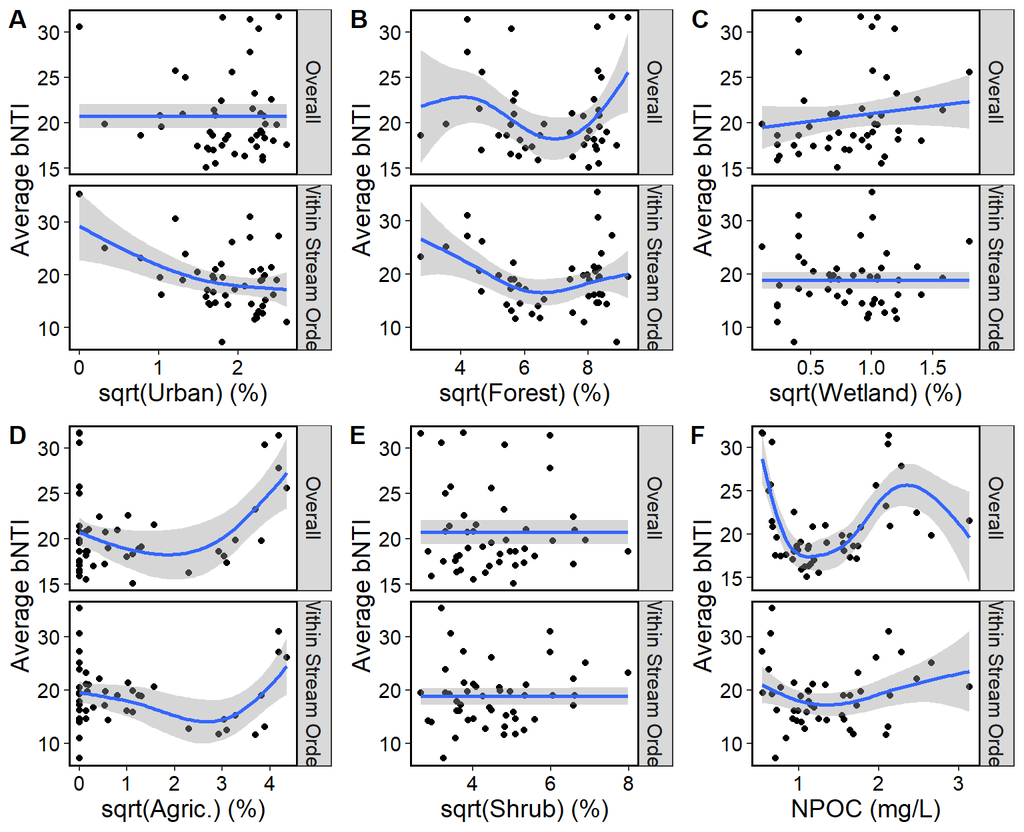

```r
supp.fig.3
```

```r
ggsave("Figures/Supplemental_Figure_4.pdf", supp.fig.3, width = 8.5, height = 7)
```

Somewhat surprisingly, very little is strongly correlated to average bNTI either across the entire dataset or within the stream order - I’m not 100% sure what to make of this at the moment. Focusing on what we can make sense of, however, we do see some exciting patterns. Specifically, we see a unimodal relationship between either stream order or total basin area and average betaNTI within stream order. Using a generalized additive model, we see that total basin area is indeed significantly, non-linearly related to average bNTI calculated within stream orders (F-stat: 5.13098, p ~ 0.003). This indicates that significantly more determinism (and thereby diversification factors) are occurring at middling stream orders/medium sized streams than either at small or large streams. I’m not 100% sold on why this might be, but it obviously suggest that there is some optimal biogeochemical conditions at this point. I know WROL has suggested this dynamic previously for microbial communities, but I have not read too deeply into the mechanism.

As a means of confirmation, I have also run some comparisons with land cover variables and NPOC to see if any of these other so-far important variables highlighted similar dynamics to the unimodal basin area distribution and we cannot see the same patterns (even if some relationships may be significant). This points to distinct scale-based behavior rather than specific land cover influences (but that doesn’t discount *all* impacts from land cover differences, of course).